# NLME

Kushal Shah

4/5/2020

### Setup and Read-in

```r
library(tidyverse)
library(stats)
library(lme4)
library(nlme)

dat <- readRDS("dat.rds")
dat_old <- readRDS("dat_old.rds")
```

### Bell Curve Functional Form

We begin with the assumption that the normal distribution kernel, scaled by a constant, appears to be a good approximation. Here, we have three parameters that can be customized to every country: d (constant that changes the height of the curve), mu (approximately represents the day of peak cases), and var (spread of the bell curve).

```r
# Functional form of new COVID cases
bellcurve.model <- function(d, mu, var, x) {
  f <- d*exp(-((x - mu)^2) / (2*var))
  return(f)
}
```

## Modeling the Old Dataset

Using data from approximately ten days ago, called `dat_old`.

### Nonlinear Mixed Effects Model (Old Dataset)

Uses the nlme function of the nlme library to fit a nonlinear mixed model. Here, every country is given a random effect for d, mu, and var. We start at fixed estimates of d=1000, mu=20, var=20.

The model updates following the base model are something I don’t fully understand yet, but each update increase the accuracy of the model.

```r
# NLME model using old dataset
baseModel <- nlme(new_cases ~ bellcurve.model(d, mu, var, x = day),
                  data = dat_old,
                  fixed = list(d ~ 1, mu ~ 1, var ~ 1),
                  random = d + mu + var ~ 1|Country.Region,
                  start = list(fixed = c(1000, 20, 20)),
                  na.action = na.omit)

# Updates to increase accuracy of the model
nestedModel <- update(baseModel, fixed = list(d ~ 1, mu ~ 1, var ~ 1), start = fixef(baseModel))
nestedModel2 <- update(nestedModel, fixed = list(d ~ 1, mu ~ 1, var ~ 1), start = fixef(nestedModel))
```

### Model Summary

#### Fixed Effects

```r
# Fixed effects of the model parameters
summary(nestedModel2)
```

```
## Nonlinear mixed-effects model fit by maximum likelihood
##   Model: new_cases ~ bellcurve.model(d, mu, var, x = day)
##  Data: dat_old
##       AIC     BIC    logLik
##   18364.7 18415.6 -9172.348
##
## Random effects:
##  Formula: list(d ~ 1, mu ~ 1, var ~ 1)
##  Level: Country.Region
##  Structure: General positive-definite, Log-Cholesky parametrization
##          StdDev      Corr
## d        1564.496491 d      mu
## mu          4.190375  0.502
## var        16.919309 -0.403  0.189
## Residual  456.688140
##
## Fixed effects: list(d ~ 1, mu ~ 1, var ~ 1)
##        Value Std.Error   DF   t-value p-value
## d   687.2124 200.73639 1100  3.423457   6e-04
## mu   20.0589   1.34967 1100 14.862056   0e+00
## var  66.0950   7.98229 1100  8.280207   0e+00
##  Correlation:
##     d      mu
## mu   0.395
## var -0.073  0.537
##
## Standardized Within-Group Residuals:
##         Min          Q1         Med          Q3         Max
## -7.91450582 -0.07481647 -0.02193235  0.02778881 24.88349328
##
## Number of Observations: 1200
## Number of Groups: 98
```

#### Random Effects

```r
# Random effects of the model parameters by country
ranef(nestedModel2)
```

```
##                                  d            mu           var
## Albania                -487.332748 -0.5642002151   2.141062692
## Algeria                -396.542289 -0.4195207151   1.745316498
## Andorra                -154.620853 -0.0980270163   0.641168748
## Argentina              -344.639674 -0.3435777930   1.518401503
## Armenia                -402.030646 -0.4304870672   1.779626427
## Australia              -489.134243 -0.3568732845   2.349031135
## Austria                  45.255834  1.0161279740   0.007860478
## Azerbaijan              -53.631192 -0.0168897342   0.197238101
## Bahrain                -653.666925 -0.8729746151   2.853101388
## Belarus                -314.501547 -0.2902275698   1.358686169
## Belgium                -215.831053  0.1344236014   1.029450306
## Bosnia and Herzegovina -159.251265 -0.1034468423   0.665048623
## Brazil                   71.274132  0.1955147149  -0.557687674
## Brunei                 -559.077172 -0.6912387922   2.456852359
## Bulgaria               -501.347371 -0.5944130036   2.215604727
## Burkina Faso            -38.131284 -0.0105467614   0.139457135
## Cambodia                -99.611836 -0.0477289603   0.392993130
## Cameroon                 -5.415580 -0.0003030166   0.016760181
## Canada                 -322.756361  0.0085147671   1.524927253
## Chile                  -308.093401 -0.3197785117   1.409233439
## China                  3549.724110 -1.6633351400 -10.207729613
## Colombia               -369.729903 -0.3820583761   1.636437338
## Costa Rica             -247.972495 -0.2048548512   1.066891080
## Croatia                -337.322063 -0.3332112004   1.486587888
## Cyprus                 -172.000109 -0.1136987127   0.712511246
## Czechia                -386.028534 -0.4905712595   1.787066313
## Denmark                -503.980765 -0.7433184314   2.373115279
## Dominican Republic       -7.394527 -0.0041435013   0.035444371
## Ecuador                 212.094419 -0.0202613643  -0.892164042
## Egypt                  -619.028521 -0.8130212813   2.715453346
## Estonia                -563.235123 -0.7127216125   2.504145757
## Finland                -519.331855 -0.6500075816   2.328454914
## France                 2099.790304  7.2865415437  -3.869362044
## Georgia                 -25.791884 -0.0045598977   0.087249340
## Germany                2881.403363  3.2965334086 -25.412334787
## Greece                 -586.926388 -0.7692451362   2.596449331
## Hungary                -343.634234 -0.3357826801   1.500292937
## Iceland                -602.492382 -0.7883724810   2.638735860
## India                  -561.700097 -0.6997132583   2.474691619
```

[output cut: 44 more lines]

```
## Sri Lanka              -299.878360 -0.2696711262   1.291392288
## Sweden                 -501.659552 -0.7945932785   2.217947925
## Switzerland             555.383651  2.9060771867  -2.465234136
## Taiwan*                -583.673284 -0.7397992654   2.566696517
## Thailand               -567.135004 -0.6825103074   2.506527282
## Trinidad and Tobago     -29.959702 -0.0056747130   0.101728410
## Tunisia                 -98.097810 -0.0462691484   0.385500241
## Turkey                  509.847879 -0.6220968414  -2.008430027
## Ukraine                 -22.091098 -0.0041501777   0.076438011
## United Arab Emirates   -636.810991 -0.8360953749   2.786171059
## United Kingdom          209.680512  2.2620678705  -0.654587308
## Uruguay                -246.865265 -0.2053535033   1.068253711
## US                     8691.761135  8.8410183299 -51.479933290
## Venezuela               -52.900988 -0.0170835270   0.196604361
## Vietnam                -581.601554 -0.7330313230   2.554379715
```

### Model Fit and Predictions for USA

From the following output, it seems like the model had good predictions on the USA data and accurately has the peak of the bell curve not occuring well past the latest day available in the dataset.

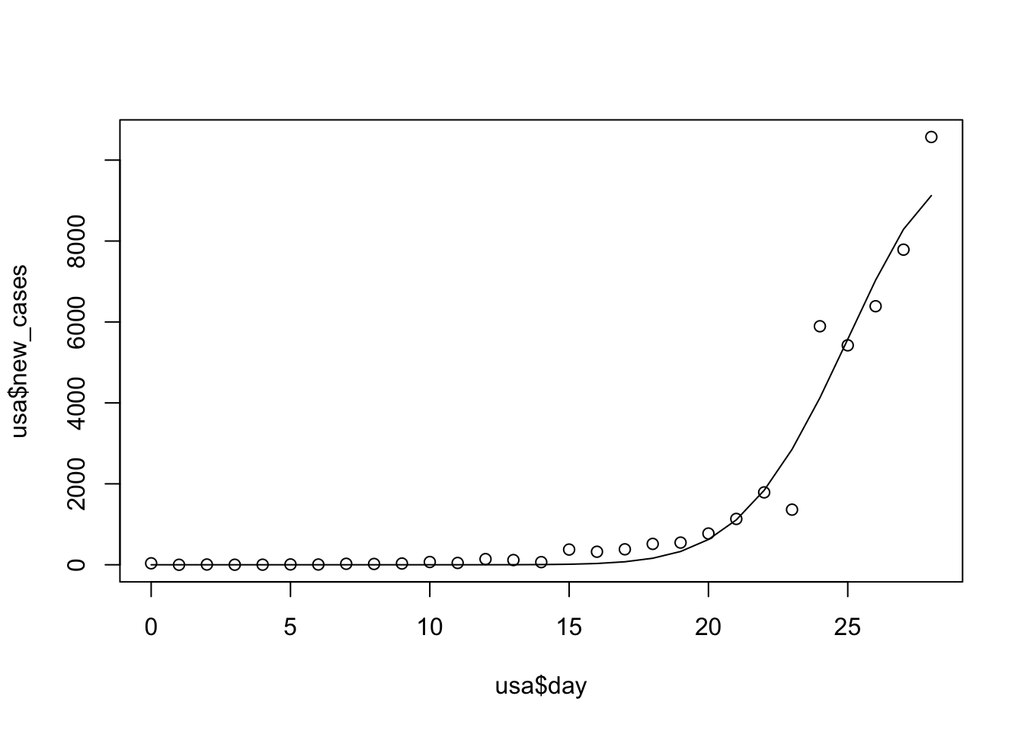

```r
# Data manipulation to create USA predictions in the next step
usa <- filter(dat_old, Country.Region == "US")
preds <- predict(nestedModel2)
preds_dat <- data.frame(country = attr(preds, "names"), pred = preds)
preds_dat_usa <- preds_dat %>%
  filter(country == "US")
preds_dat_usa <- preds_dat_usa %>%
  mutate(day = as.numeric(rownames(preds_dat_usa)) - 1)

# Model has great predictions on USA data up till March 25, predicting a normal curve with peak new cases at day 29
plot(usa$day, usa$new_cases)
lines(preds_dat_usa$day, preds_dat_usa$pred)
```

## Modeling the New Dataset

Now we try to run the same model using the new data, called `dat`. If you uncomment this code and run it, you’ll get an error: `Error in nlme.formula(new_cases ~ bellcurve.model(d, mu, var, x = day), : Singularity in backsolve at level 0, block 1`

```r
#baseModel2 <- nlme(new_cases ~ bellcurve.model(d, mu, var, x = day),
#                  data = dat,
#                  fixed = list(d ~ 1, mu ~ 1, var ~ 1),
#                  random = d + mu + var ~ 1|Country.Region,
#                  start = list(fixed = c(1000, 20, 20)),
#                  na.action = na.omit)
```